# Computational and Numerical Methods

# G. All real roots of $x^4 − x − 1=0$

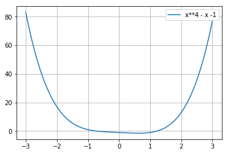

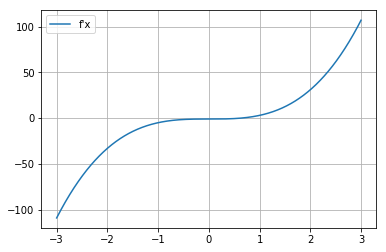

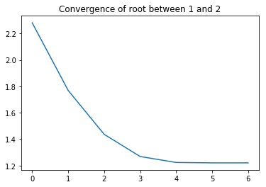

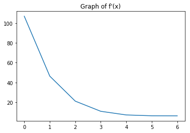

```
Steps taken to converge in Bisection Method are 14
Steps taken to converge in Newton Raphson are 8
```

|  | n | x(n) | f(x) | f'(x) | x(n) - x(n-1) | x(n+1) | x(n+1) - x(n) |
| --- | --- | --- | --- | --- | --- | --- | --- |
| 0 | 0.0 | 3.000000 | 77.000000 | 107.000000 | 0.000000 | 2.280374 | -0.719626 |
| 1 | 1.0 | 2.280374 | 23.760716 | 46.432732 | -0.719626 | 1.768650 | -0.511723 |
| 2 | 2.0 | 1.768650 | 7.016511 | 21.130233 | -0.511723 | 1.436590 | -0.332060 |
| 3 | 3.0 | 1.436590 | 1.822644 | 10.859288 | -0.332060 | 1.268748 | -0.167842 |
| 4 | 4.0 | 1.268748 | 0.322457 | 7.169327 | -0.167842 | 1.223771 | -0.044977 |
| 5 | 5.0 | 1.223771 | 0.019081 | 6.330952 | -0.044977 | 1.220757 | -0.003014 |
| 6 | 6.0 | 1.220757 | 0.000081 | 6.276922 | -0.003014 | 1.220744 | -0.000013 |

```python
table = pd.DataFrame(columns=['n', 'x(n)', 'f(x)', "f'(x)", 'x(n) - x(n-1)', 'x(n+1)', 'x(n+1) - x(n)'])

n    = 0
x_n  = 3
f_x  = x_n**4 -x_n -1
dfdx = 4*x_n**3 -1
dif1 = 0
x_n1 = x_n - (f_x/dfdx)
dif2 = x_n1 - x_n
table.loc[0] = [n, x_n, f_x, dfdx, dif1, x_n1, dif2]

while(1):
  n += 1
  dif1 = x_n1 - x_n
  x_n = x_n1
  f_x  = x_n**4 -x_n -1
  dfdx = 4*x_n**3 -1
  x_n1 = x_n - (f_x/dfdx)
  dif2 = x_n1 - x_n
  table.loc[n] = [n, x_n, f_x, dfdx, dif1, x_n1, dif2]
  if(abs(dif2) < 0.0001):
    break
x = np.arange(-3,3,0.001)
y = x**4 - x -1
plot(x,y,"x**4 - x -1")
plot(x,4*(x**3)-1,"f'x")
plt.plot(table['n'], table['x(n+1)'])
plt.title("Convergence of root between 1 and 2")
plt.show()
plt.plot(table["n"], table["f'(x)"])
plt.title("Graph of f'(x)")
plt.show()
print("Steps taken to converge in Bisection Method are 14")
print("Steps taken to converge in Newton Raphson are 8")

table
```

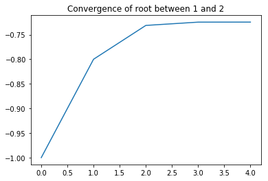

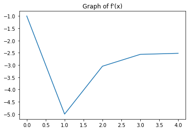

```
Steps taken to converge in Bisection Method are 14
Steps taken to converge in Newton Raphson are 6
```

|  | n | x(n) | f(x) | f'(x) | x(n) - x(n-1) | x(n+1) | x(n+1) - x(n) |
| --- | --- | --- | --- | --- | --- | --- | --- |
| 0 | 0.0 | 0.000000 | -1.000000 | -1.000000 | 0.000000 | -1.000000 | -1.000000 |
| 1 | 1.0 | -1.000000 | 1.000000 | -5.000000 | -1.000000 | -0.800000 | 0.200000 |
| 2 | 2.0 | -0.800000 | 0.209600 | -3.048000 | 0.200000 | -0.731234 | 0.068766 |
| 3 | 3.0 | -0.731234 | 0.017140 | -2.563970 | 0.068766 | -0.724548 | 0.006685 |
| 4 | 4.0 | -0.724548 | 0.000143 | -2.521466 | 0.006685 | -0.724492 | 0.000057 |

```python
table = pd.DataFrame(columns=['n', 'x(n)', 'f(x)', "f'(x)", 'x(n) - x(n-1)', 'x(n+1)', 'x(n+1) - x(n)'])

n    = 0
x_n  = 0
f_x  = x_n**4 -x_n -1
dfdx = 4*x_n**3 -1
dif1 = 0
x_n1 = x_n - (f_x/dfdx)
dif2 = x_n1 - x_n
table.loc[0] = [n, x_n, f_x, dfdx, dif1, x_n1, dif2]

while(1):
  n += 1
  dif1 = x_n1 - x_n
  x_n = x_n1
  f_x  = x_n**4 -x_n -1
  dfdx = 4*x_n**3 -1
  x_n1 = x_n - (f_x/dfdx)
  dif2 = x_n1 - x_n
  table.loc[n] = [n, x_n, f_x, dfdx, dif1, x_n1, dif2]
  if(abs(dif2) < 0.0001):
    break


plt.plot(table['n'], table['x(n+1)'])
plt.title("Convergence of root between 1 and 2")
plt.show()
plt.plot(table["n"], table["f'(x)"])
plt.title("Graph of f'(x)")
plt.show()
print("Steps taken to converge in Bisection Method are 14")
print("Steps taken to converge in Newton Raphson are 6")

table
```

# $ F. x^3 − 2x − 2=0$

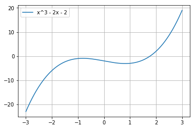

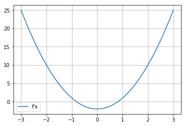

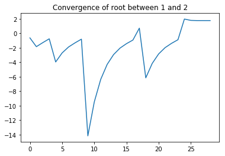

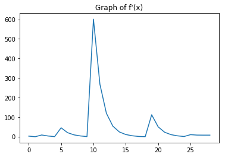

[output not shown]

|  | n | x(n) | f(x) | f'(x) | x(n) - x(n-1) | x(n+1) | x(n+1) - x(n) |
| --- | --- | --- | --- | --- | --- | --- | --- |
| 0 | 0.0 | -1.200000 | -1.328000 | 2.320000 | 0.000000 | -0.627586 | 5.724138e-01 |
| 1 | 1.0 | -0.627586 | -0.992011 | -0.818407 | 0.572414 | -1.839712 | -1.212125e+00 |
| 2 | 2.0 | -1.839712 | -4.547152 | 8.153616 | -1.212125 | -1.282026 | 5.576853e-01 |
| 3 | 3.0 | -1.282026 | -1.543075 | 2.930774 | 0.557685 | -0.755519 | 5.265076e-01 |
| 4 | 4.0 | -0.755519 | -0.920219 | -0.287574 | 0.526508 | -3.955452 | -3.199933e+00 |
| 5 | 5.0 | -3.955452 | -55.974519 | 44.936802 | -3.199933 | -2.709824 | 1.245628e+00 |
| 6 | 6.0 | -2.709824 | -16.478995 | 20.029446 | 1.245628 | -1.887086 | 8.227384e-01 |
| 7 | 7.0 | -1.887086 | -4.945918 | 8.683281 | 0.822738 | -1.317495 | 5.695909e-01 |
| 8 | 8.0 | -1.317495 | -1.651909 | 3.207380 | 0.569591 | -0.802461 | 5.150338e-01 |
| 9 | 9.0 | -0.802461 | -0.911818 | -0.068167 | 0.515034 | -14.178625 | -1.337616e+01 |
| 10 | 10.0 | -14.178625 | -2824.019743 | 601.100179 | -13.376163 | -9.480539 | 4.698085e+00 |
| 11 | 11.0 | -9.480539 | -835.155775 | 267.641887 | 4.698085 | -6.360117 | 3.120423e+00 |
| 12 | 12.0 | -6.360117 | -246.553416 | 119.353263 | 3.120423 | -4.294372 | 2.065745e+00 |
| 13 | 13.0 | -4.294372 | -72.606473 | 53.324890 | 2.065745 | -2.932785 | 1.361587e+00 |
| 14 | 14.0 | -2.932785 | -21.359981 | 23.803683 | 1.361587 | -2.035446 | 8.973393e-01 |
| 15 | 15.0 | -2.035446 | -6.362039 | 10.429117 | 0.897339 | -1.425419 | 6.100266e-01 |
| 16 | 16.0 | -1.425419 | -2.045356 | 4.095458 | 0.610027 | -0.925998 | 4.994206e-01 |
| 17 | 17.0 | -0.925998 | -0.942022 | 0.572419 | 0.499421 | 0.719687 | 1.645685e+00 |
| 18 | 18.0 | 0.719687 | -3.066613 | -0.446152 | 1.645685 | -6.153780 | -6.873467e+00 |
| 19 | 19.0 | -6.153780 | -222.730035 | 111.607041 | -6.873467 | -4.158118 | 1.995663e+00 |
| 20 | 20.0 | -4.158118 | -65.577372 | 49.869824 | 1.995663 | -2.843147 | 1.314971e+00 |
| 21 | 21.0 | -2.843147 | -19.296231 | 22.250446 | 1.314971 | -1.975918 | 8.672289e-01 |
| 22 | 22.0 | -1.975918 | -5.762641 | 9.712751 | 0.867229 | -1.382611 | 5.933068e-01 |
| 23 | 23.0 | -1.382611 | -1.877794 | 3.734837 | 0.593307 | -0.879833 | 5.027781e-01 |
| 24 | 24.0 | -0.879833 | -0.921418 | 0.322316 | 0.502778 | 1.978906 | 2.858738e+00 |
| 25 | 25.0 | 1.978906 | 1.791717 | 9.748203 | 2.858738 | 1.795106 | -1.837997e-01 |
| 26 | 26.0 | 1.795106 | 0.194347 | 7.667216 | -0.183800 | 1.769758 | -2.534779e-02 |
| 27 | 27.0 | 1.769758 | 0.003444 | 7.396132 | -0.025348 | 1.769293 | -4.656267e-04 |
| 28 | 28.0 | 1.769293 | 0.000001 | 7.391188 | -0.000466 | 1.769292 | -1.557251e-07 |

```python
table = pd.DataFrame(columns=['n', 'x(n)', 'f(x)', "f'(x)", 'x(n) - x(n-1)', 'x(n+1)', 'x(n+1) - x(n)'])

n    = 0
x_n  = -1.2
f_x  = x_n**3 -2*x_n -2
dfdx = 3*x_n**2 - 2
dif1 = 0
x_n1 = x_n - (f_x/dfdx)
dif2 = x_n1 - x_n
table.loc[0] = [n, x_n, f_x, dfdx, dif1, x_n1, dif2]

while(1):
  n += 1
  dif1 = x_n1 - x_n
  x_n = x_n1
  f_x  = x_n**3 -2*x_n -2
  dfdx = 3*x_n**2 - 2
  x_n1 = x_n - (f_x/dfdx)
  dif2 = x_n1 - x_n
  table.loc[n] = [n, x_n, f_x, dfdx, dif1, x_n1, dif2]
  if(abs(dif2) < 0.0001):
    break
x = np.arange(-3,3,0.001)
y  = x**3 -2*x -2
dfdx = 3*x**2 - 2
plot(x,y,"x^3 - 2x - 2")
plot(x,dfdx,"f'x")
plt.plot(table['n'], table['x(n+1)'])
plt.title("Convergence of root between 1 and 2")
plt.show()
plt.plot(table["n"], table["f'(x)"])
plt.title("Graph of f'(x)")
plt.show()
print("Steps taken to converge in Bisection Method are 17")
print("Steps taken to converge in Newton Raphson are 5")

table
```

# 2. Find the largest root of $f(x) = e^x − x − 2=0$, with $\epsilon = 0.0001$.

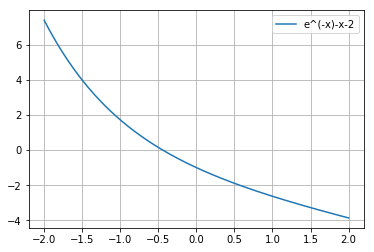

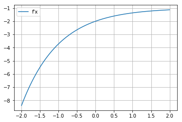

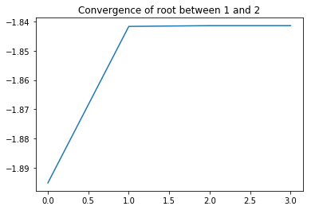

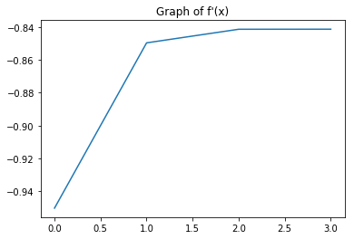

```
Steps taken to converge in Bisection Method are 14
Steps taken to converge in Newton Raphson are 5
```

|  | n | x(n) | f(x) | f'(x) | x(n) - x(n-1) | x(n+1) | x(n+1) - x(n) |
| --- | --- | --- | --- | --- | --- | --- | --- |
| 0 | 0.0 | -3.000000 | 1.049787e+00 | -0.950213 | 0.000000 | -1.895209 | 1.104791e+00 |
| 1 | 1.0 | -1.895209 | 4.549559e-02 | -0.849713 | 1.104791 | -1.841666 | 5.354230e-02 |
| 2 | 2.0 | -1.841666 | 2.193164e-04 | -0.841447 | 0.053542 | -1.841406 | 2.606420e-04 |
| 3 | 3.0 | -1.841406 | 5.386056e-09 | -0.841406 | 0.000261 | -1.841406 | 6.401260e-09 |

```python
table = pd.DataFrame(columns=['n', 'x(n)', 'f(x)', "f'(x)", 'x(n) - x(n-1)', 'x(n+1)', 'x(n+1) - x(n)'])

n    = 0
x_n  = -3
f_x  = np.exp(x_n) -x_n -2
dfdx = np.exp(x_n) -1
dif1 = 0
x_n1 = x_n - (f_x/dfdx)
dif2 = x_n1 - x_n
table.loc[0] = [n, x_n, f_x, dfdx, dif1, x_n1, dif2]

while(1):
  n += 1
  dif1 = x_n1 - x_n
  x_n = x_n1
  f_x  = np.exp(x_n) -x_n -2
  dfdx = np.exp(x_n) -1
  x_n1 = x_n - (f_x/dfdx)
  dif2 = x_n1 - x_n
  table.loc[n] = [n, x_n, f_x, dfdx, dif1, x_n1, dif2]
  if(abs(dif2) < 0.0001):
    break
x = np.arange(-2,2,0.001)
y = np.exp(-1*x) -(x)-2
plot(x,y,"e^(-x)-x-2")
plot(x,-np.exp(-x)-1,"f'x")
plt.plot(table['n'], table['x(n+1)'])
plt.title("Convergence of root between 1 and 2")
plt.show()
plt.plot(table["n"], table["f'(x)"])
plt.title("Graph of f'(x)")
plt.show()
print("Steps taken to converge in Bisection Method are 14")
print("Steps taken to converge in Newton Raphson are 5")

table
```

# Find the smallest positive root of $ f(x)=1 − x + sinx = 0$, with $\epsilon = 0.0001$.

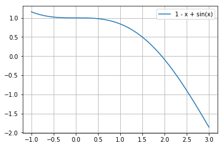

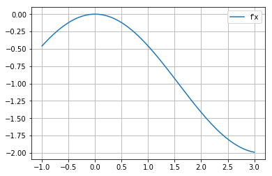

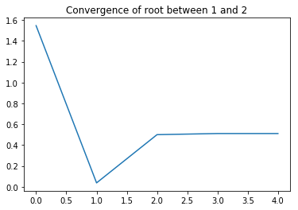

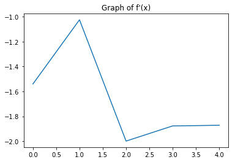

```
Steps taken to converge in Bisection Method are 14
Steps taken to converge in Newton Raphson are 6
```

|  | n | x(n) | f(x) | f'(x) | x(n) - x(n-1) | x(n+1) | x(n+1) - x(n) |
| --- | --- | --- | --- | --- | --- | --- | --- |
| 0 | 0.0 | 1.000000 | 0.841471 | -1.540302 | 0.000000 | 1.546302 | 0.546302 |
| 1 | 1.0 | 1.546302 | -1.546003 | -1.024491 | 0.546302 | 0.037259 | -1.509044 |
| 2 | 2.0 | 0.037259 | 0.925492 | -1.999306 | -1.509044 | 0.500165 | 0.462906 |
| 3 | 3.0 | 0.500165 | 0.020265 | -1.877503 | 0.462906 | 0.510958 | 0.010793 |
| 4 | 4.0 | 0.510958 | 0.000028 | -1.872276 | 0.010793 | 0.510973 | 0.000015 |

```python
table = pd.DataFrame(columns=['n', 'x(n)', 'f(x)', "f'(x)", 'x(n) - x(n-1)', 'x(n+1)', 'x(n+1) - x(n)'])

n    = 0
x_n  = 1
f_x  = 1 -x_n +np.sin(x_n)
dfdx = -1 -np.cos(x_n)
dif1 = 0
x_n1 = x_n - (f_x/dfdx)
dif2 = x_n1 - x_n
table.loc[0] = [n, x_n, f_x, dfdx, dif1, x_n1, dif2]

while(1):
  n += 1
  dif1 = x_n1 - x_n
  x_n = x_n1
  f_x  = 1 -x_n -np.sin(x_n)
  dfdx = -1 -np.cos(x_n)
  x_n1 = x_n - (f_x/dfdx)
  dif2 = x_n1 - x_n
  table.loc[n] = [n, x_n, f_x, dfdx, dif1, x_n1, dif2]
  if(abs(dif2) < 0.0001):
    break
x = np.arange(-1,3,0.001)
y = 1 - x +np.sin(x)
plot(x,y,"1 - x + sin(x)")
plot(x,-1+np.cos(x),"f'x")
plt.plot(table['n'], table['x(n+1)'])
plt.title("Convergence of root between 1 and 2")
plt.show()
plt.plot(table["n"], table["f'(x)"])
plt.title("Graph of f'(x)")
plt.show()
print("Steps taken to converge in Bisection Method are 14")
print("Steps taken to converge in Newton Raphson are 6")

table
```

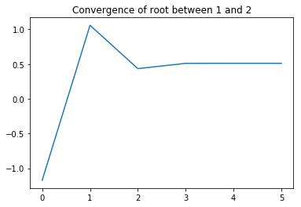

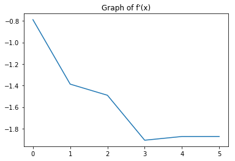

```
Steps taken to converge in Bisection Method are 14
Steps taken to converge in Newton Raphson are 7
```

|  | n | x(n) | f(x) | f'(x) | x(n) - x(n-1) | x(n+1) | x(n+1) - x(n) |
| --- | --- | --- | --- | --- | --- | --- | --- |
| 0 | 0.0 | 4.500000 | -4.477530e+00 | -0.789204 | 0.000000 | -1.173475 | -5.673475e+00 |
| 1 | 1.0 | -1.173475 | 3.095575e+00 | -1.386950 | -5.673475 | 1.058455 | 2.231930e+00 |
| 2 | 2.0 | 1.058455 | -9.300548e-01 | -1.490219 | 2.231930 | 0.434349 | -6.241062e-01 |
| 3 | 3.0 | 0.434349 | 1.448305e-01 | -1.907144 | -0.624106 | 0.510290 | 7.594105e-02 |
| 4 | 4.0 | 0.510290 | 1.279057e-03 | -1.872603 | 0.075941 | 0.510973 | 6.830369e-04 |
| 5 | 5.0 | 0.510973 | 1.139824e-07 | -1.872269 | 0.000683 | 0.510973 | 6.087929e-08 |

```python
table = pd.DataFrame(columns=['n', 'x(n)', 'f(x)', "f'(x)", 'x(n) - x(n-1)', 'x(n+1)', 'x(n+1) - x(n)'])

n    = 0
x_n  = 4.5
f_x  = 1 -x_n +np.sin(x_n)
dfdx = -1 -np.cos(x_n)
dif1 = 0
x_n1 = x_n - (f_x/dfdx)
dif2 = x_n1 - x_n
table.loc[0] = [n, x_n, f_x, dfdx, dif1, x_n1, dif2]

while(1):
  n += 1
  dif1 = x_n1 - x_n
  x_n = x_n1
  f_x  = 1 -x_n -np.sin(x_n)
  dfdx = -1 -np.cos(x_n)
  x_n1 = x_n - (f_x/dfdx)
  dif2 = x_n1 - x_n
  table.loc[n] = [n, x_n, f_x, dfdx, dif1, x_n1, dif2]
  if(abs(dif2) < 0.0001):
    break


plt.plot(table['n'], table['x(n+1)'])
plt.title("Convergence of root between 1 and 2")
plt.show()
plt.plot(table["n"], table["f'(x)"])
plt.title("Graph of f'(x)")
plt.show()
print("Steps taken to converge in Bisection Method are 14")
print("Steps taken to converge in Newton Raphson are 7")

table
```

# 4. Find the smallest non-zero positive root of $x = tanx$, with an accuracy of $\epsilon = 0.0001$. Further solve for the root that is closest to $x = 100$.

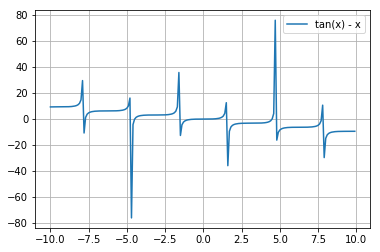

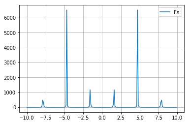

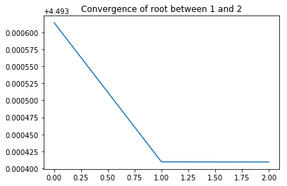

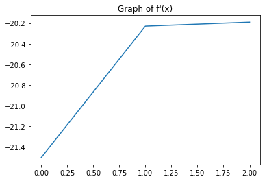

```
Steps taken to converge in Bisection Method are 19
Steps taken to converge in Newton Raphson are 4
```

|  | n | x(n) | f(x) | f'(x) | x(n) - x(n-1) | x(n+1) | x(n+1) - x(n) |
| --- | --- | --- | --- | --- | --- | --- | --- |
| 0 | 0.0 | 4.500000 | -0.137332 | -21.504849 | 0.000000 | 4.493614 | -6.386097e-03 |
| 1 | 1.0 | 4.493614 | -0.004132 | -20.229717 | -0.006386 | 4.493410 | -2.042477e-04 |
| 2 | 2.0 | 4.493410 | -0.000004 | -20.190766 | -0.000204 | 4.493409 | -1.971040e-07 |

```python
table = pd.DataFrame(columns=['n', 'x(n)', 'f(x)', "f'(x)", 'x(n) - x(n-1)', 'x(n+1)', 'x(n+1) - x(n)'])

n    = 0
x_n  = 4.5
f_x  = x_n - np.tan(x_n)
dfdx = 1 - (np.cos(x_n)**(-2))
dif1 = 0
x_n1 = x_n - (f_x/dfdx)
dif2 = x_n1 - x_n
table.loc[0] = [n, x_n, f_x, dfdx, dif1, x_n1, dif2]

while(1):
  n += 1
  dif1 = x_n1 - x_n
  x_n = x_n1
  f_x  = x_n - np.tan(x_n)
  dfdx = 1 - (np.cos(x_n)**(-2))
  x_n1 = x_n - (f_x/dfdx)
  dif2 = x_n1 - x_n
  table.loc[n] = [n, x_n, f_x, dfdx, dif1, x_n1, dif2]
  if(abs(dif2) < 0.0001):
    break
x = np.arange(-10,10,0.1)
y = np.tan(x) - x
plot(x,y,"tan(x) - x")
plot(x,(np.cos(x))**(-2) -1,"f'x")
plt.plot(table['n'], table['x(n+1)'])
plt.title("Convergence of root between 1 and 2")
plt.show()
plt.plot(table["n"], table["f'(x)"])
plt.title("Graph of f'(x)")
plt.show()
print("Steps taken to converge in Bisection Method are 19")
print("Steps taken to converge in Newton Raphson are 4")

table
```

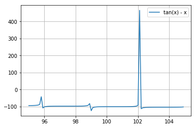

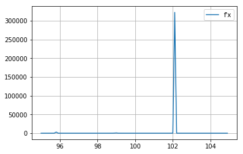

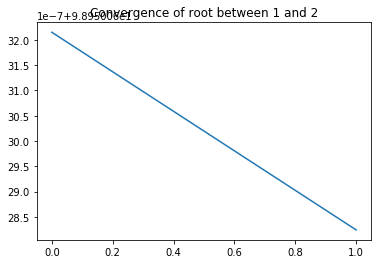

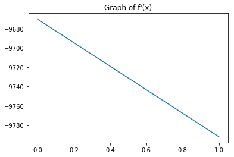

```
Steps taken to converge in Bisection Method are 17
Steps taken to converge in Newton Raphson are 2
```

|  | n | x(n) | f(x) | f'(x) | x(n) - x(n-1) | x(n+1) | x(n+1) - x(n) |
| --- | --- | --- | --- | --- | --- | --- | --- |
| 0 | 0.0 | 98.950000 | 0.611320 | -9670.496060 | 0.000000 | 98.950063 | 6.321492e-05 |
| 1 | 1.0 | 98.950063 | -0.003824 | -9791.871878 | 0.000063 | 98.950063 | -3.905708e-07 |

```python
table = pd.DataFrame(columns=['n', 'x(n)', 'f(x)', "f'(x)", 'x(n) - x(n-1)', 'x(n+1)', 'x(n+1) - x(n)'])

n    = 0
x_n  = 98.95
f_x  = x_n - np.tan(x_n)
dfdx = 1 - (np.cos(x_n)**(-2))
dif1 = 0
x_n1 = x_n - (f_x/dfdx)
dif2 = x_n1 - x_n
table.loc[0] = [n, x_n, f_x, dfdx, dif1, x_n1, dif2]

while(1):
  n += 1
  dif1 = x_n1 - x_n
  x_n = x_n1
  f_x  = x_n - np.tan(x_n)
  dfdx = 1 - (np.cos(x_n)**(-2))
  x_n1 = x_n - (f_x/dfdx)
  dif2 = x_n1 - x_n
  table.loc[n] = [n, x_n, f_x, dfdx, dif1, x_n1, dif2]
  if(abs(dif2) < 0.0001):
    break

x = np.arange(95,105,0.1)
y = np.tan(x) - x
plot(x,y,"tan(x) - x")
plot(x,(np.cos(x))**(-2) -1,"f'x")
plt.plot(table['n'], table['x(n+1)'])
plt.title("Convergence of root between 1 and 2")
plt.show()
plt.plot(table["n"], table["f'(x)"])
plt.title("Graph of f'(x)")
plt.show()
print("Steps taken to converge in Bisection Method are 17")
print("Steps taken to converge in Newton Raphson are 2")

table
```

# The function $y=f(x)=a+x(x−1)^{2}$,with $0≤a≤0.1$. When $a \neq 0$, there is only one real root of f(x) = 0, with the root being negative. Analytically check how many roots are obtained for a = 0, and what is the nature of the roots. Thereafter, using the Newton-Raphson method, test for the convergence towards the negative real root, through a series of suitably chosen a values going right down to a = 0 (the most important case). In every case your initial guess value should be slightly larger than 1, say 1.01, and slightly smaller than 1, say 0.99. For every value of a, starting from both sides of x = 1, check how quickly the convergence happens.

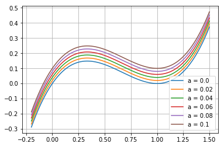

|  | n | x(n) | f(x) | f'(x) | x(n) - x(n-1) | x(n+1) | x(n+1) - x(n) |
| --- | --- | --- | --- | --- | --- | --- | --- |
| 0 | 0.0 | 1.010000 | 1.010000e-04 | 0.020300 | 0.000000 | 1.005025 | -0.004975 |
| 1 | 1.0 | 1.005025 | 2.537377e-05 | 0.010125 | -0.004975 | 1.002519 | -0.002506 |
| 2 | 2.0 | 1.002519 | 6.359220e-06 | 0.005056 | -0.002506 | 1.001261 | -0.001258 |
| 3 | 3.0 | 1.001261 | 1.591797e-06 | 0.002527 | -0.001258 | 1.000631 | -0.000630 |
| 4 | 4.0 | 1.000631 | 3.981995e-07 | 0.001263 | -0.000630 | 1.000316 | -0.000315 |
| 5 | 5.0 | 1.000316 | 9.958124e-08 | 0.000631 | -0.000315 | 1.000158 | -0.000158 |
| 6 | 6.0 | 1.000158 | 2.489923e-08 | 0.000316 | -0.000158 | 1.000079 | -0.000079 |

```python
x = np.arange(-0.2, 1.5, 0.001)

d={}
for a in range(0, 12, 2):
  y = (a/100) + x*((x-1)**2)
  plt.plot(x, y, label='a = '+ str(a/100))
  d[a/2] = pd.DataFrame(columns=['n', 'x(n)', 'f(x)', "f'(x)", 'x(n) - x(n-1)', 'x(n+1)', 'x(n+1) - x(n)'])

  n    = 0
  x_n  = 1.01
  f_x  = (a/100) + x_n*((x_n-1)**2)
  dfdx = ((x_n-1)**2) + (2*x_n*(x_n-1))
  dif1 = 0
  x_n1 = x_n - (f_x/dfdx)
  dif2 = x_n1 - x_n
  d[a/2].loc[0] = [n, x_n, f_x, dfdx, dif1, x_n1, dif2]

  while(1):
    n += 1
    dif1 = x_n1 - x_n
    x_n = x_n1
    f_x  = (a/100) + x_n*((x_n-1)**2)
    dfdx = ((x_n-1)**2) + (2*x_n*(x_n-1))
    x_n1 = x_n - (f_x/dfdx)
    dif2 = x_n1 - x_n
    d[a/2].loc[n] = [n, x_n, f_x, dfdx, dif1, x_n1, dif2]
    if(abs(dif2) < 0.0001):
      break

plt.grid(True)
plt.legend()
plt.show()
d[0]
```

```python
d[1]
```

|  | n | x(n) | f(x) | f'(x) | x(n) - x(n-1) | x(n+1) | x(n+1) - x(n) |
| --- | --- | --- | --- | --- | --- | --- | --- |
| 0 | 0.0 | 1.010000 | 0.020101 | 0.020300 | 0.000000 | 0.019803 | -0.990197 |
| 1 | 1.0 | 0.019803 | 0.039026 | 0.921965 | -0.990197 | -0.022527 | -0.042330 |
| 2 | 2.0 | -0.022527 | -0.003553 | 1.091629 | -0.042330 | -0.019272 | 0.003255 |
| 3 | 3.0 | -0.019272 | -0.000022 | 1.078202 | 0.003255 | -0.019252 | 0.000020 |

```python
d[2]
```

|  | n | x(n) | f(x) | f'(x) | x(n) - x(n-1) | x(n+1) | x(n+1) - x(n) |
| --- | --- | --- | --- | --- | --- | --- | --- |
| 0 | 0.0 | 1.010000 | 0.040101 | 0.020300 | 0.000000 | -0.965419 | -1.975419 |
| 1 | 1.0 | -0.965419 | -3.689288 | 7.657775 | -1.975419 | -0.483649 | 0.481770 |
| 2 | 2.0 | -0.483649 | -1.024613 | 3.636342 | 0.481770 | -0.201878 | 0.281770 |
| 3 | 3.0 | -0.201878 | -0.251615 | 1.929777 | 0.281770 | -0.071492 | 0.130386 |
| 4 | 4.0 | -0.071492 | -0.042080 | 1.301304 | 0.130386 | -0.039155 | 0.032337 |
| 5 | 5.0 | -0.039155 | -0.002282 | 1.161221 | 0.032337 | -0.037190 | 0.001965 |
| 6 | 6.0 | -0.037190 | -0.000008 | 1.152911 | 0.001965 | -0.037183 | 0.000007 |

```python
d[3]
```

|  | n | x(n) | f(x) | f'(x) | x(n) - x(n-1) | x(n+1) | x(n+1) - x(n) |
| --- | --- | --- | --- | --- | --- | --- | --- |
| 0 | 0.0 | 1.010000 | 0.060101 | 0.020300 | 0.000000 | -1.950640 | -2.960640 |
| 1 | 1.0 | -1.950640 | -16.922819 | 20.217555 | -2.960640 | -1.113605 | 0.837036 |
| 2 | 2.0 | -1.113605 | -4.914832 | 9.174763 | 0.837036 | -0.577914 | 0.535690 |
| 3 | 3.0 | -0.577914 | -1.378898 | 4.313611 | 0.535690 | -0.258252 | 0.319662 |
| 4 | 4.0 | -0.258252 | -0.348864 | 2.233090 | 0.319662 | -0.102027 | 0.156225 |
| 5 | 5.0 | -0.102027 | -0.063908 | 1.439337 | 0.156225 | -0.057626 | 0.044401 |
| 6 | 6.0 | -0.057626 | -0.004459 | 1.240466 | 0.044401 | -0.054031 | 0.003594 |
| 7 | 7.0 | -0.054031 | -0.000028 | 1.224884 | 0.003594 | -0.054009 | 0.000023 |

```python
d[4]
```

|  | n | x(n) | f(x) | f'(x) | x(n) - x(n-1) | x(n+1) | x(n+1) - x(n) |
| --- | --- | --- | --- | --- | --- | --- | --- |
| 0 | 0.0 | 1.010000 | 0.080101 | 0.020300 | 0.000000 | -2.935862 | -3.945862 |
| 1 | 1.0 | -2.935862 | -45.399469 | 38.601307 | -3.945862 | -1.759750 | 1.176112 |
| 2 | 2.0 | -1.759750 | -13.322640 | 17.329158 | 1.176112 | -0.990951 | 0.768799 |
| 3 | 3.0 | -0.990951 | -3.848015 | 7.909753 | 0.768799 | -0.504461 | 0.486490 |
| 4 | 4.0 | -0.504461 | -1.061798 | 3.781286 | 0.486490 | -0.223657 | 0.280803 |
| 5 | 5.0 | -0.223657 | -0.254891 | 2.044698 | 0.280803 | -0.098998 | 0.124659 |
| 6 | 6.0 | -0.098998 | -0.039570 | 1.425394 | 0.124659 | -0.071238 | 0.027760 |
| 7 | 7.0 | -0.071238 | -0.001749 | 1.300175 | 0.027760 | -0.069893 | 0.001345 |
| 8 | 8.0 | -0.069893 | -0.000004 | 1.294225 | 0.001345 | -0.069890 | 0.000003 |

```python
d[5]
```

|  | n | x(n) | f(x) | f'(x) | x(n) - x(n-1) | x(n+1) | x(n+1) - x(n) |
| --- | --- | --- | --- | --- | --- | --- | --- |
| 0 | 0.0 | 1.010000 | 1.001010e-01 | 0.020300 | 0.000000 | -3.921084 | -4.931084e+00 |
| 1 | 1.0 | -3.921084 | -9.485714e+01 | 62.809028 | -4.931084 | -2.410837 | 1.510247e+00 |
| 2 | 2.0 | -2.410837 | -2.794721e+01 | 28.079750 | 1.510247 | -1.415557 | 9.952800e-01 |
| 3 | 3.0 | -1.415557 | -8.159654e+00 | 12.673631 | 0.995280 | -0.771728 | 6.438292e-01 |
| 4 | 4.0 | -0.771728 | -2.322468e+00 | 5.873601 | 0.643829 | -0.376320 | 3.954078e-01 |
| 5 | 5.0 | -0.376320 | -6.128463e-01 | 2.930129 | 0.395408 | -0.167167 | 2.091533e-01 |
| 6 | 6.0 | -0.167167 | -1.277273e-01 | 1.752500 | 0.209153 | -0.094284 | 7.288288e-02 |
| 7 | 7.0 | -0.094284 | -1.290060e-02 | 1.403803 | 0.072883 | -0.085094 | 9.189755e-03 |
| 8 | 8.0 | -0.085094 | -1.920143e-04 | 1.362099 | 0.009190 | -0.084953 | 1.409695e-04 |
| 9 | 9.0 | -0.084953 | -4.481505e-08 | 1.361463 | 0.000141 | -0.084953 | 3.291684e-08 |

```python
d[1]
```

|  | n | x(n) | f(x) | f'(x) | x(n) - x(n-1) | x(n+1) | x(n+1) - x(n) |
| --- | --- | --- | --- | --- | --- | --- | --- |
| 0 | 0.0 | 1.010000 | 0.020101 | 0.020300 | 0.000000 | 0.019803 | -0.990197 |
| 1 | 1.0 | 0.019803 | 0.039026 | 0.921965 | -0.990197 | -0.022527 | -0.042330 |
| 2 | 2.0 | -0.022527 | -0.003553 | 1.091629 | -0.042330 | -0.019272 | 0.003255 |
| 3 | 3.0 | -0.019272 | -0.000022 | 1.078202 | 0.003255 | -0.019252 | 0.000020 |

```python
d[2]
```

|  | n | x(n) | f(x) | f'(x) | x(n) - x(n-1) | x(n+1) | x(n+1) - x(n) |
| --- | --- | --- | --- | --- | --- | --- | --- |
| 0 | 0.0 | 1.010000 | 0.040101 | 0.020300 | 0.000000 | -0.965419 | -1.975419 |
| 1 | 1.0 | -0.965419 | -3.689288 | 7.657775 | -1.975419 | -0.483649 | 0.481770 |
| 2 | 2.0 | -0.483649 | -1.024613 | 3.636342 | 0.481770 | -0.201878 | 0.281770 |
| 3 | 3.0 | -0.201878 | -0.251615 | 1.929777 | 0.281770 | -0.071492 | 0.130386 |
| 4 | 4.0 | -0.071492 | -0.042080 | 1.301304 | 0.130386 | -0.039155 | 0.032337 |
| 5 | 5.0 | -0.039155 | -0.002282 | 1.161221 | 0.032337 | -0.037190 | 0.001965 |
| 6 | 6.0 | -0.037190 | -0.000008 | 1.152911 | 0.001965 | -0.037183 | 0.000007 |

```python
d[3]
```

|  | n | x(n) | f(x) | f'(x) | x(n) - x(n-1) | x(n+1) | x(n+1) - x(n) |
| --- | --- | --- | --- | --- | --- | --- | --- |
| 0 | 0.0 | 1.010000 | 0.060101 | 0.020300 | 0.000000 | -1.950640 | -2.960640 |
| 1 | 1.0 | -1.950640 | -16.922819 | 20.217555 | -2.960640 | -1.113605 | 0.837036 |
| 2 | 2.0 | -1.113605 | -4.914832 | 9.174763 | 0.837036 | -0.577914 | 0.535690 |
| 3 | 3.0 | -0.577914 | -1.378898 | 4.313611 | 0.535690 | -0.258252 | 0.319662 |
| 4 | 4.0 | -0.258252 | -0.348864 | 2.233090 | 0.319662 | -0.102027 | 0.156225 |
| 5 | 5.0 | -0.102027 | -0.063908 | 1.439337 | 0.156225 | -0.057626 | 0.044401 |
| 6 | 6.0 | -0.057626 | -0.004459 | 1.240466 | 0.044401 | -0.054031 | 0.003594 |
| 7 | 7.0 | -0.054031 | -0.000028 | 1.224884 | 0.003594 | -0.054009 | 0.000023 |

```python
d[4]
```

|  | n | x(n) | f(x) | f'(x) | x(n) - x(n-1) | x(n+1) | x(n+1) - x(n) |
| --- | --- | --- | --- | --- | --- | --- | --- |
| 0 | 0.0 | 1.010000 | 0.080101 | 0.020300 | 0.000000 | -2.935862 | -3.945862 |
| 1 | 1.0 | -2.935862 | -45.399469 | 38.601307 | -3.945862 | -1.759750 | 1.176112 |
| 2 | 2.0 | -1.759750 | -13.322640 | 17.329158 | 1.176112 | -0.990951 | 0.768799 |
| 3 | 3.0 | -0.990951 | -3.848015 | 7.909753 | 0.768799 | -0.504461 | 0.486490 |
| 4 | 4.0 | -0.504461 | -1.061798 | 3.781286 | 0.486490 | -0.223657 | 0.280803 |
| 5 | 5.0 | -0.223657 | -0.254891 | 2.044698 | 0.280803 | -0.098998 | 0.124659 |
| 6 | 6.0 | -0.098998 | -0.039570 | 1.425394 | 0.124659 | -0.071238 | 0.027760 |
| 7 | 7.0 | -0.071238 | -0.001749 | 1.300175 | 0.027760 | -0.069893 | 0.001345 |
| 8 | 8.0 | -0.069893 | -0.000004 | 1.294225 | 0.001345 | -0.069890 | 0.000003 |

```python
d[5]
```

|  | n | x(n) | f(x) | f'(x) | x(n) - x(n-1) | x(n+1) | x(n+1) - x(n) |
| --- | --- | --- | --- | --- | --- | --- | --- |
| 0 | 0.0 | 1.010000 | 1.001010e-01 | 0.020300 | 0.000000 | -3.921084 | -4.931084e+00 |
| 1 | 1.0 | -3.921084 | -9.485714e+01 | 62.809028 | -4.931084 | -2.410837 | 1.510247e+00 |
| 2 | 2.0 | -2.410837 | -2.794721e+01 | 28.079750 | 1.510247 | -1.415557 | 9.952800e-01 |
| 3 | 3.0 | -1.415557 | -8.159654e+00 | 12.673631 | 0.995280 | -0.771728 | 6.438292e-01 |
| 4 | 4.0 | -0.771728 | -2.322468e+00 | 5.873601 | 0.643829 | -0.376320 | 3.954078e-01 |
| 5 | 5.0 | -0.376320 | -6.128463e-01 | 2.930129 | 0.395408 | -0.167167 | 2.091533e-01 |
| 6 | 6.0 | -0.167167 | -1.277273e-01 | 1.752500 | 0.209153 | -0.094284 | 7.288288e-02 |
| 7 | 7.0 | -0.094284 | -1.290060e-02 | 1.403803 | 0.072883 | -0.085094 | 9.189755e-03 |
| 8 | 8.0 | -0.085094 | -1.920143e-04 | 1.362099 | 0.009190 | -0.084953 | 1.409695e-04 |
| 9 | 9.0 | -0.084953 | -4.481505e-08 | 1.361463 | 0.000141 | -0.084953 | 3.291684e-08 |

# The function $y = f(x) = ax(1 − x)$, with $a = ±1$, has two roots at $x = 0,1$ and a turning point at $x = 1/2$. Use the Newton-Raphson method to test the convergence towards $x = 0$, starting from an initial value of 0.51. Similarly test the convergence towards x = 1, starting from 0.49. Perform this exercise for both signs of a. Repeat this entire exercise for initial values of 0.501, 0.5001 and 0.499, 0.4999, respectively.

## For $a = 1$:

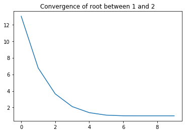

|  | n | x(n) | f(x) | f'(x) | x(n) - x(n-1) | x(n+1) | x(n+1) - x(n) |
| --- | --- | --- | --- | --- | --- | --- | --- |
| 0 | 0.0 | 0.510000 | 2.499000e-01 | -0.020000 | 0.100000 | 13.005000 | 1.249500e+01 |
| 1 | 1.0 | 13.005000 | -1.561250e+02 | -25.010000 | 12.495000 | 6.762496 | -6.242504e+00 |
| 2 | 2.0 | 6.762496 | -3.896886e+01 | -12.524992 | -6.242504 | 3.651208 | -3.111288e+00 |
| 3 | 3.0 | 3.651208 | -9.680112e+00 | -6.302416 | -3.111288 | 2.115271 | -1.535937e+00 |
| 4 | 4.0 | 2.115271 | -2.359102e+00 | -3.230543 | -1.535937 | 1.385022 | -7.302493e-01 |
| 5 | 5.0 | 1.385022 | -5.332641e-01 | -1.770044 | -0.730249 | 1.083750 | -3.012716e-01 |
| 6 | 6.0 | 1.083750 | -9.076459e-02 | -1.167501 | -0.301272 | 1.006008 | -7.774263e-02 |
| 7 | 7.0 | 1.006008 | -6.043916e-03 | -1.012016 | -0.077743 | 1.000036 | -5.972157e-03 |
| 8 | 8.0 | 1.000036 | -3.566666e-05 | -1.000071 | -0.005972 | 1.000000 | -3.566411e-05 |
| 9 | 9.0 | 1.000000 | -1.271929e-09 | -1.000000 | -0.000036 | 1.000000 | -1.271929e-09 |

```python
table = pd.DataFrame(columns=['n', 'x(n)', 'f(x)', "f'(x)", 'x(n) - x(n-1)', 'x(n+1)', 'x(n+1) - x(n)'])

n    = 0
x_n  = 0.51
f_x  = x_n*(1-x_n)
dfdx = 1 - 2*x_n
dif1 = 0.1
x_n1 = x_n - (f_x/dfdx)
dif2 = x_n1 - x_n
table.loc[0] = [n, x_n, f_x, dfdx, dif1, x_n1, dif2]

while(1):
  n += 1
  dif1 = x_n1 - x_n
  x_n = x_n1
  f_x  = x_n*(1-x_n)
  dfdx = 1 - 2*x_n
  x_n1 = x_n - (f_x/dfdx)
  dif2 = x_n1 - x_n
  table.loc[n] = [n, x_n, f_x, dfdx, dif1, x_n1, dif2]
  if(abs(dif1) < 0.0001):
    break
x = np.arange(-1,1,0.01)
y = x*(1-x)
plot(x,y,"x*(1-x)")
plot(x,1-2*x,"f'x")
plt.plot(table['n'], table['x(n+1)'])
plt.title("Convergence of root between 1 and 2")
plt.show()

table
```

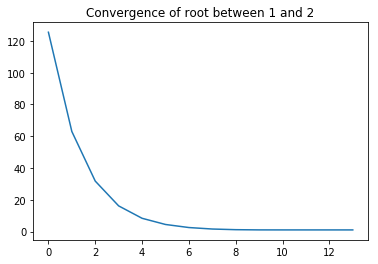

|  | n | x(n) | f(x) | f'(x) | x(n) - x(n-1) | x(n+1) | x(n+1) - x(n) |
| --- | --- | --- | --- | --- | --- | --- | --- |
| 0 | 0.0 | 0.501000 | 2.499990e-01 | -0.002000 | 1.000000e-01 | 125.500500 | 1.249995e+02 |
| 1 | 1.0 | 125.500500 | -1.562488e+04 | -250.001000 | 1.249995e+02 | 63.001250 | -6.249925e+01 |
| 2 | 2.0 | 63.001250 | -3.906156e+03 | -125.002500 | -6.249925e+01 | 31.752625 | -3.124863e+01 |
| 3 | 3.0 | 31.752625 | -9.764766e+02 | -62.505250 | -3.124863e+01 | 16.130312 | -1.562231e+01 |
| 4 | 4.0 | 16.130312 | -2.440567e+02 | -31.260624 | -1.562231e+01 | 8.323153 | -7.807159e+00 |
| 5 | 5.0 | 8.323153 | -6.095173e+01 | -15.646307 | -7.807159e+00 | 4.427555 | -3.895598e+00 |
| 6 | 6.0 | 4.427555 | -1.517569e+01 | -7.855110 | -3.895598e+00 | 2.495604 | -1.931951e+00 |
| 7 | 7.0 | 2.495604 | -3.732435e+00 | -3.991208 | -1.931951e+00 | 1.560440 | -9.351642e-01 |
| 8 | 8.0 | 1.560440 | -8.745322e-01 | -2.120879 | -9.351642e-01 | 1.148095 | -4.123442e-01 |
| 9 | 9.0 | 1.148095 | -1.700277e-01 | -1.296191 | -4.123442e-01 | 1.016921 | -1.311749e-01 |
| 10 | 10.0 | 1.016921 | -1.720685e-02 | -1.033841 | -1.311749e-01 | 1.000277 | -1.664362e-02 |
| 11 | 11.0 | 1.000277 | -2.770099e-04 | -1.000554 | -1.664362e-02 | 1.000000 | -2.768566e-04 |
| 12 | 12.0 | 1.000000 | -7.664958e-08 | -1.000000 | -2.768566e-04 | 1.000000 | -7.664957e-08 |
| 13 | 13.0 | 1.000000 | -5.773160e-15 | -1.000000 | -7.664957e-08 | 1.000000 | -5.773160e-15 |

```python
table = pd.DataFrame(columns=['n', 'x(n)', 'f(x)', "f'(x)", 'x(n) - x(n-1)', 'x(n+1)', 'x(n+1) - x(n)'])

n    = 0
x_n  = 0.501
f_x  = x_n*(1-x_n)
dfdx = 1 - 2*x_n
dif1 = 0.1
x_n1 = x_n - (f_x/dfdx)
dif2 = x_n1 - x_n
table.loc[0] = [n, x_n, f_x, dfdx, dif1, x_n1, dif2]

while(1):
  n += 1
  dif1 = x_n1 - x_n
  x_n = x_n1
  f_x  = x_n*(1-x_n)
  dfdx = 1 - 2*x_n
  x_n1 = x_n - (f_x/dfdx)
  dif2 = x_n1 - x_n
  table.loc[n] = [n, x_n, f_x, dfdx, dif1, x_n1, dif2]
  if(abs(dif1) < 0.0001):
    break
x = np.arange(-1,1,0.01)
y = x*(1-x)
plot(x,y,"x*(1-x)")
plot(x,1-2*x,"f'x")
plt.plot(table['n'], table['x(n+1)'])
plt.title("Convergence of root between 1 and 2")
plt.show()

table
```

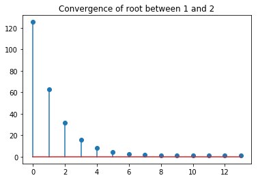

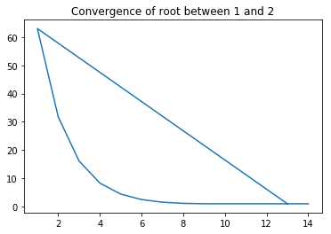

|  | n | x(n) | f(x) | f'(x) | x(n) - x(n-1) | x(n+1) | x(n+1) - x(n) |
| --- | --- | --- | --- | --- | --- | --- | --- |
| 0 | 13.0 | 1.000000 | -5.773160e-15 | -1.000000 | 1.000000e-01 | 1.000000 | -5.773160e-15 |
| 1 | 1.0 | 125.500500 | -1.562488e+04 | -250.001000 | 1.249995e+02 | 63.001250 | -6.249925e+01 |
| 2 | 2.0 | 63.001250 | -3.906156e+03 | -125.002500 | -6.249925e+01 | 31.752625 | -3.124863e+01 |
| 3 | 3.0 | 31.752625 | -9.764766e+02 | -62.505250 | -3.124863e+01 | 16.130312 | -1.562231e+01 |
| 4 | 4.0 | 16.130312 | -2.440567e+02 | -31.260624 | -1.562231e+01 | 8.323153 | -7.807159e+00 |
| 5 | 5.0 | 8.323153 | -6.095173e+01 | -15.646307 | -7.807159e+00 | 4.427555 | -3.895598e+00 |
| 6 | 6.0 | 4.427555 | -1.517569e+01 | -7.855110 | -3.895598e+00 | 2.495604 | -1.931951e+00 |
| 7 | 7.0 | 2.495604 | -3.732435e+00 | -3.991208 | -1.931951e+00 | 1.560440 | -9.351642e-01 |
| 8 | 8.0 | 1.560440 | -8.745322e-01 | -2.120879 | -9.351642e-01 | 1.148095 | -4.123442e-01 |
| 9 | 9.0 | 1.148095 | -1.700277e-01 | -1.296191 | -4.123442e-01 | 1.016921 | -1.311749e-01 |
| 10 | 10.0 | 1.016921 | -1.720685e-02 | -1.033841 | -1.311749e-01 | 1.000277 | -1.664362e-02 |
| 11 | 11.0 | 1.000277 | -2.770099e-04 | -1.000554 | -1.664362e-02 | 1.000000 | -2.768566e-04 |
| 12 | 12.0 | 1.000000 | -7.664958e-08 | -1.000000 | -2.768566e-04 | 1.000000 | -7.664957e-08 |
| 13 | 13.0 | 1.000000 | -5.773160e-15 | -1.000000 | -7.664957e-08 | 1.000000 | -5.773160e-15 |
| 14 | 14.0 | 1.000000 | 0.000000e+00 | -1.000000 | -5.773160e-15 | 1.000000 | 0.000000e+00 |

```python
table = pd.DataFrame(columns=['n', 'x(n)', 'f(x)', "f'(x)", 'x(n) - x(n-1)', 'x(n+1)', 'x(n+1) - x(n)'])

n    = 0
x_n  = 0.5001
f_x  = x_n*(1-x_n)
table = pd.DataFrame(columns=['n', 'x(n)', 'f(x)', "f'(x)", 'x(n) - x(n-1)', 'x(n+1)', 'x(n+1) - x(n)'])

n    = 0
x_n  = 0.501
f_x  = x_n*(1-x_n)
dfdx = 1 - 2*x_n
dif1 = 0.1
x_n1 = x_n - (f_x/dfdx)
dif2 = x_n1 - x_n
table.loc[0] = [n, x_n, f_x, dfdx, dif1, x_n1, dif2]

while(1):
  n += 1
  dif1 = x_n1 - x_n
  x_n = x_n1
  f_x  = x_n*(1-x_n)
  dfdx = 1 - 2*x_n
  x_n1 = x_n - (f_x/dfdx)
  dif2 = x_n1 - x_n
  table.loc[n] = [n, x_n, f_x, dfdx, dif1, x_n1, dif2]
  if(abs(dif1) < 0.0001):
    break
x = np.arange(-1,1,0.01)
y = x*(1-x)
plot(x,y,"x*(1-x)")
plot(x,1-2*x,"f'x")
plt.stem(table['n'], table['x(n+1)'])
plt.title("Convergence of root between 1 and 2")
plt.show()

table
dfdx = 1 - 2*x_n
dif1 = 0.1
x_n1 = x_n - (f_x/dfdx)
dif2 = x_n1 - x_n
table.loc[0] = [n, x_n, f_x, dfdx, dif1, x_n1, dif2]

while(1):
  n += 1
  dif1 = x_n1 - x_n
  x_n = x_n1
  f_x  = x_n*(1-x_n)
  dfdx = 1 - 2*x_n
  x_n1 = x_n - (f_x/dfdx)
  dif2 = x_n1 - x_n
  table.loc[n] = [n, x_n, f_x, dfdx, dif1, x_n1, dif2]
  if(abs(dif1) < 0.0001):
    break

y = x*(1-x)
plot(x,y,"x*(1-x)")
plot(x,1-2*x,"f'x")
plt.plot(table['n'], table['x(n+1)'])
plt.title("Convergence of root between 1 and 2")
plt.show()

table
```

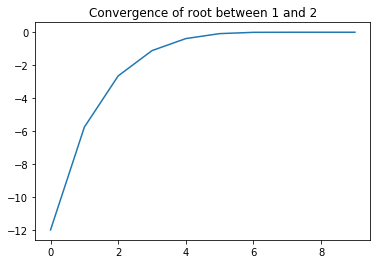

|  | n | x(n) | f(x) | f'(x) | x(n) - x(n-1) | x(n+1) | x(n+1) - x(n) |
| --- | --- | --- | --- | --- | --- | --- | --- |
| 0 | 0.0 | 4.900000e-01 | 2.499000e-01 | 0.020000 | 0.100000 | -1.200500e+01 | -1.249500e+01 |
| 1 | 1.0 | -1.200500e+01 | -1.561250e+02 | 25.010000 | -12.495000 | -5.762496e+00 | 6.242504e+00 |
| 2 | 2.0 | -5.762496e+00 | -3.896886e+01 | 12.524992 | 6.242504 | -2.651208e+00 | 3.111288e+00 |
| 3 | 3.0 | -2.651208e+00 | -9.680112e+00 | 6.302416 | 3.111288 | -1.115271e+00 | 1.535937e+00 |
| 4 | 4.0 | -1.115271e+00 | -2.359102e+00 | 3.230543 | 1.535937 | -3.850221e-01 | 7.302493e-01 |
| 5 | 5.0 | -3.850221e-01 | -5.332641e-01 | 1.770044 | 0.730249 | -8.375045e-02 | 3.012716e-01 |
| 6 | 6.0 | -8.375045e-02 | -9.076459e-02 | 1.167501 | 0.301272 | -6.007822e-03 | 7.774263e-02 |
| 7 | 7.0 | -6.007822e-03 | -6.043916e-03 | 1.012016 | 0.077743 | -3.566538e-05 | 5.972157e-03 |
| 8 | 8.0 | -3.566538e-05 | -3.566666e-05 | 1.000071 | 0.005972 | -1.271929e-09 | 3.566411e-05 |
| 9 | 9.0 | -1.271929e-09 | -1.271929e-09 | 1.000000 | 0.000036 | -1.617803e-18 | 1.271929e-09 |

```python
table = pd.DataFrame(columns=['n', 'x(n)', 'f(x)', "f'(x)", 'x(n) - x(n-1)', 'x(n+1)', 'x(n+1) - x(n)'])

n    = 0
x_n  = 0.49
f_x  = x_n*(1-x_n)
dfdx = 1 - 2*x_n
dif1 = 0.1
x_n1 = x_n - (f_x/dfdx)
dif2 = x_n1 - x_n
table.loc[0] = [n, x_n, f_x, dfdx, dif1, x_n1, dif2]

while(1):
  n += 1
  dif1 = x_n1 - x_n
  x_n = x_n1
  f_x  = x_n*(1-x_n)
  dfdx = 1 - 2*x_n
  x_n1 = x_n - (f_x/dfdx)
  dif2 = x_n1 - x_n
  table.loc[n] = [n, x_n, f_x, dfdx, dif1, x_n1, dif2]
  if(abs(dif1) < 0.0001):
    break
x = np.arange(-1,1,0.01)
y = x*(1-x)
plot(x,y,"x*(1-x)")
plot(x,1-2*x,"f'x")
plt.plot(table['n'], table['x(n+1)'])
plt.title("Convergence of root between 1 and 2")
plt.show()

table
```

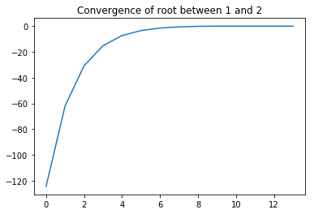

|  | n | x(n) | f(x) | f'(x) | x(n) - x(n-1) | x(n+1) | x(n+1) - x(n) |
| --- | --- | --- | --- | --- | --- | --- | --- |
| 0 | 0.0 | 4.990000e-01 | 2.499990e-01 | 0.002000 | 1.000000e-01 | -1.245005e+02 | -1.249995e+02 |
| 1 | 1.0 | -1.245005e+02 | -1.562488e+04 | 250.001000 | -1.249995e+02 | -6.200125e+01 | 6.249925e+01 |
| 2 | 2.0 | -6.200125e+01 | -3.906156e+03 | 125.002500 | 6.249925e+01 | -3.075262e+01 | 3.124863e+01 |
| 3 | 3.0 | -3.075262e+01 | -9.764766e+02 | 62.505250 | 3.124863e+01 | -1.513031e+01 | 1.562231e+01 |
| 4 | 4.0 | -1.513031e+01 | -2.440567e+02 | 31.260624 | 1.562231e+01 | -7.323153e+00 | 7.807159e+00 |
| 5 | 5.0 | -7.323153e+00 | -6.095173e+01 | 15.646307 | 7.807159e+00 | -3.427555e+00 | 3.895598e+00 |
| 6 | 6.0 | -3.427555e+00 | -1.517569e+01 | 7.855110 | 3.895598e+00 | -1.495604e+00 | 1.931951e+00 |
| 7 | 7.0 | -1.495604e+00 | -3.732435e+00 | 3.991208 | 1.931951e+00 | -5.604396e-01 | 9.351642e-01 |
| 8 | 8.0 | -5.604396e-01 | -8.745322e-01 | 2.120879 | 9.351642e-01 | -1.480954e-01 | 4.123442e-01 |
| 9 | 9.0 | -1.480954e-01 | -1.700277e-01 | 1.296191 | 4.123442e-01 | -1.692055e-02 | 1.311749e-01 |
| 10 | 10.0 | -1.692055e-02 | -1.720685e-02 | 1.033841 | 1.311749e-01 | -2.769333e-04 | 1.664362e-02 |
| 11 | 11.0 | -2.769333e-04 | -2.770099e-04 | 1.000554 | 1.664362e-02 | -7.664958e-08 | 2.768566e-04 |
| 12 | 12.0 | -7.664958e-08 | -7.664958e-08 | 1.000000 | 2.768566e-04 | -5.875157e-15 | 7.664957e-08 |
| 13 | 13.0 | -5.875157e-15 | -5.875157e-15 | 1.000000 | 7.664957e-08 | -3.549874e-29 | 5.875157e-15 |

```python
table = pd.DataFrame(columns=['n', 'x(n)', 'f(x)', "f'(x)", 'x(n) - x(n-1)', 'x(n+1)', 'x(n+1) - x(n)'])

n    = 0
x_n  = 0.499
f_x  = x_n*(1-x_n)
dfdx = 1 - 2*x_n
dif1 = 0.1
x_n1 = x_n - (f_x/dfdx)
dif2 = x_n1 - x_n
table.loc[0] = [n, x_n, f_x, dfdx, dif1, x_n1, dif2]

while(1):
  n += 1
  dif1 = x_n1 - x_n
  x_n = x_n1
  f_x  = x_n*(1-x_n)
  dfdx = 1 - 2*x_n
  x_n1 = x_n - (f_x/dfdx)
  dif2 = x_n1 - x_n
  table.loc[n] = [n, x_n, f_x, dfdx, dif1, x_n1, dif2]
  if(abs(dif1) < 0.0001):
    break
x = np.arange(-1,1,0.01)
y = x*(1-x)
plot(x,y,"x*(1-x)")
plot(x,1-2*x,"f'x")
plt.plot(table['n'], table['x(n+1)'])
plt.title("Convergence of root between 1 and 2")
plt.show()

table
```

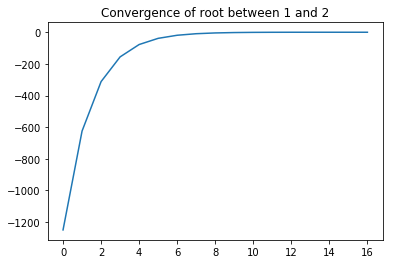

|  | n | x(n) | f(x) | f'(x) | x(n) - x(n-1) | x(n+1) | x(n+1) - x(n) |
| --- | --- | --- | --- | --- | --- | --- | --- |
| 0 | 0.0 | 4.999000e-01 | 2.500000e-01 | 0.000200 | 0.100000 | -1.249500e+03 | -1.250000e+03 |
| 1 | 1.0 | -1.249500e+03 | -1.562500e+06 | 2500.000100 | -1249.999950 | -6.245001e+02 | 6.249999e+02 |
| 2 | 2.0 | -6.245001e+02 | -3.906249e+05 | 1250.000250 | 624.999925 | -3.120003e+02 | 3.124999e+02 |
| 3 | 3.0 | -3.120003e+02 | -9.765616e+04 | 625.000525 | 312.499863 | -1.557505e+02 | 1.562497e+02 |
| 4 | 4.0 | -1.557505e+02 | -2.441398e+04 | 312.501062 | 156.249731 | -7.762607e+01 | 7.812447e+01 |
| 5 | 5.0 | -7.762607e+01 | -6.103432e+03 | 156.252131 | 78.124466 | -3.856463e+01 | 3.906143e+01 |
| 6 | 6.0 | -3.856463e+01 | -1.525796e+03 | 78.129266 | 39.061433 | -1.903552e+01 | 1.952912e+01 |
| 7 | 7.0 | -1.903552e+01 | -3.813864e+02 | 39.071032 | 19.529117 | -9.274157e+00 | 9.761360e+00 |
| 8 | 8.0 | -9.274157e+00 | -9.528414e+01 | 19.548313 | 9.761360 | -4.399867e+00 | 4.874290e+00 |
| 9 | 9.0 | -4.399867e+00 | -2.375870e+01 | 9.799734 | 4.874290 | -1.975444e+00 | 2.424423e+00 |
| 10 | 10.0 | -1.975444e+00 | -5.877825e+00 | 4.950889 | 2.424423 | -7.882182e-01 | 1.187226e+00 |
| 11 | 11.0 | -7.882182e-01 | -1.409506e+00 | 2.576436 | 1.187226 | -2.411424e-01 | 5.470759e-01 |
| 12 | 12.0 | -2.411424e-01 | -2.992920e-01 | 1.482285 | 0.547076 | -3.922974e-02 | 2.019126e-01 |
| 13 | 13.0 | -3.922974e-02 | -4.076871e-02 | 1.078459 | 0.201913 | -1.427010e-03 | 3.780273e-02 |
| 14 | 14.0 | -1.427010e-03 | -1.429046e-03 | 1.002854 | 0.037803 | -2.030562e-06 | 1.424979e-03 |
| 15 | 15.0 | -2.030562e-06 | -2.030566e-06 | 1.000004 | 0.001425 | -4.123164e-12 | 2.030557e-06 |
| 16 | 16.0 | -4.123164e-12 | -4.123164e-12 | 1.000000 | 0.000002 | -1.700082e-23 | 4.123164e-12 |

```python
table = pd.DataFrame(columns=['n', 'x(n)', 'f(x)', "f'(x)", 'x(n) - x(n-1)', 'x(n+1)', 'x(n+1) - x(n)'])

n    = 0
x_n  = 0.4999
f_x  = x_n*(1-x_n)
dfdx = 1 - 2*x_n
dif1 = 0.1
x_n1 = x_n - (f_x/dfdx)
dif2 = x_n1 - x_n
table.loc[0] = [n, x_n, f_x, dfdx, dif1, x_n1, dif2]

while(1):
  n += 1
  dif1 = x_n1 - x_n
  x_n = x_n1
  f_x  = x_n*(1-x_n)
  dfdx = 1 - 2*x_n
  x_n1 = x_n - (f_x/dfdx)
  dif2 = x_n1 - x_n
  table.loc[n] = [n, x_n, f_x, dfdx, dif1, x_n1, dif2]
  if(abs(dif1) < 0.0001):
    break

y = x*(1-x)
plot(x,y,"x*(1-x)")
plot(x,1-2*x,"f'x")
plt.plot(table['n'], table['x(n+1)'])
plt.title("Convergence of root between 1 and 2")
plt.show()

table
```

## For $a = -1$

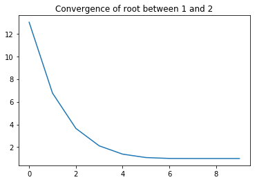

|  | n | x(n) | f(x) | f'(x) | x(n) - x(n-1) | x(n+1) | x(n+1) - x(n) |
| --- | --- | --- | --- | --- | --- | --- | --- |
| 0 | 0.0 | 0.510000 | -2.499000e-01 | 0.020000 | 0.100000 | 13.005000 | 1.249500e+01 |
| 1 | 1.0 | 13.005000 | 1.561250e+02 | 25.010000 | 12.495000 | 6.762496 | -6.242504e+00 |
| 2 | 2.0 | 6.762496 | 3.896886e+01 | 12.524992 | -6.242504 | 3.651208 | -3.111288e+00 |
| 3 | 3.0 | 3.651208 | 9.680112e+00 | 6.302416 | -3.111288 | 2.115271 | -1.535937e+00 |
| 4 | 4.0 | 2.115271 | 2.359102e+00 | 3.230543 | -1.535937 | 1.385022 | -7.302493e-01 |
| 5 | 5.0 | 1.385022 | 5.332641e-01 | 1.770044 | -0.730249 | 1.083750 | -3.012716e-01 |
| 6 | 6.0 | 1.083750 | 9.076459e-02 | 1.167501 | -0.301272 | 1.006008 | -7.774263e-02 |
| 7 | 7.0 | 1.006008 | 6.043916e-03 | 1.012016 | -0.077743 | 1.000036 | -5.972157e-03 |
| 8 | 8.0 | 1.000036 | 3.566666e-05 | 1.000071 | -0.005972 | 1.000000 | -3.566411e-05 |
| 9 | 9.0 | 1.000000 | 1.271929e-09 | 1.000000 | -0.000036 | 1.000000 | -1.271929e-09 |

```python
table = pd.DataFrame(columns=['n', 'x(n)', 'f(x)', "f'(x)", 'x(n) - x(n-1)', 'x(n+1)', 'x(n+1) - x(n)'])

n    = 0
x_n  = 0.51
f_x  = -x_n*(1-x_n)
dfdx = -1 + 2*x_n
dif1 = 0.1
x_n1 = x_n - (f_x/dfdx)
dif2 = x_n1 - x_n
table.loc[0] = [n, x_n, f_x, dfdx, dif1, x_n1, dif2]

while(1):
  n += 1
  dif1 = x_n1 - x_n
  x_n = x_n1
  f_x  = -x_n*(1-x_n)
  dfdx = -1 + 2*x_n
  x_n1 = x_n - (f_x/dfdx)
  dif2 = x_n1 - x_n
  table.loc[n] = [n, x_n, f_x, dfdx, dif1, x_n1, dif2]
  if(abs(dif1) < 0.0001):
    break
x = np.arange(-1,1,0.01)
y = -x*(1-x)
plot(x,y,"-x*(1-x)")
plot(x,-1+2*x,"f'x")
plt.plot(table['n'], table['x(n+1)'])
plt.title("Convergence of root between 1 and 2")
plt.show()

table
```

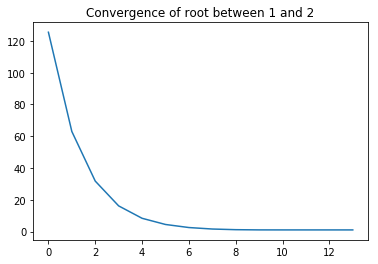

|  | n | x(n) | f(x) | f'(x) | x(n) - x(n-1) | x(n+1) | x(n+1) - x(n) |
| --- | --- | --- | --- | --- | --- | --- | --- |
| 0 | 0.0 | 0.501000 | -2.499990e-01 | 0.002000 | 1.000000e-01 | 125.500500 | 1.249995e+02 |
| 1 | 1.0 | 125.500500 | 1.562488e+04 | 250.001000 | 1.249995e+02 | 63.001250 | -6.249925e+01 |
| 2 | 2.0 | 63.001250 | 3.906156e+03 | 125.002500 | -6.249925e+01 | 31.752625 | -3.124863e+01 |
| 3 | 3.0 | 31.752625 | 9.764766e+02 | 62.505250 | -3.124863e+01 | 16.130312 | -1.562231e+01 |
| 4 | 4.0 | 16.130312 | 2.440567e+02 | 31.260624 | -1.562231e+01 | 8.323153 | -7.807159e+00 |
| 5 | 5.0 | 8.323153 | 6.095173e+01 | 15.646307 | -7.807159e+00 | 4.427555 | -3.895598e+00 |
| 6 | 6.0 | 4.427555 | 1.517569e+01 | 7.855110 | -3.895598e+00 | 2.495604 | -1.931951e+00 |
| 7 | 7.0 | 2.495604 | 3.732435e+00 | 3.991208 | -1.931951e+00 | 1.560440 | -9.351642e-01 |
| 8 | 8.0 | 1.560440 | 8.745322e-01 | 2.120879 | -9.351642e-01 | 1.148095 | -4.123442e-01 |
| 9 | 9.0 | 1.148095 | 1.700277e-01 | 1.296191 | -4.123442e-01 | 1.016921 | -1.311749e-01 |
| 10 | 10.0 | 1.016921 | 1.720685e-02 | 1.033841 | -1.311749e-01 | 1.000277 | -1.664362e-02 |
| 11 | 11.0 | 1.000277 | 2.770099e-04 | 1.000554 | -1.664362e-02 | 1.000000 | -2.768566e-04 |
| 12 | 12.0 | 1.000000 | 7.664958e-08 | 1.000000 | -2.768566e-04 | 1.000000 | -7.664957e-08 |
| 13 | 13.0 | 1.000000 | 5.773160e-15 | 1.000000 | -7.664957e-08 | 1.000000 | -5.773160e-15 |

```python
table = pd.DataFrame(columns=['n', 'x(n)', 'f(x)', "f'(x)", 'x(n) - x(n-1)', 'x(n+1)', 'x(n+1) - x(n)'])

n    = 0
x_n  = 0.501
f_x  = -x_n*(1-x_n)
dfdx = -1 + 2*x_n
dif1 = 0.1
x_n1 = x_n - (f_x/dfdx)
dif2 = x_n1 - x_n
table.loc[0] = [n, x_n, f_x, dfdx, dif1, x_n1, dif2]

while(1):
  n += 1
  dif1 = x_n1 - x_n
  x_n = x_n1
  f_x  = -x_n*(1-x_n)
  dfdx = -1 + 2*x_n
  x_n1 = x_n - (f_x/dfdx)
  dif2 = x_n1 - x_n
  table.loc[n] = [n, x_n, f_x, dfdx, dif1, x_n1, dif2]
  if(abs(dif1) < 0.0001):
    break
x = np.arange(-1,1,0.01)
y = -x*(1-x)
plot(x,y,"-x*(1-x)")
plot(x,-1+2*x,"f'x")
plt.plot(table['n'], table['x(n+1)'])
plt.title("Convergence of root between 1 and 2")
plt.show()

table
```

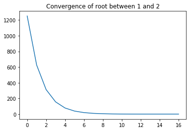

|  | n | x(n) | f(x) | f'(x) | x(n) - x(n-1) | x(n+1) | x(n+1) - x(n) |
| --- | --- | --- | --- | --- | --- | --- | --- |
| 0 | 0.0 | 0.500100 | -2.500000e-01 | 0.000200 | 0.100000 | 1250.500050 | 1.250000e+03 |
| 1 | 1.0 | 1250.500050 | 1.562500e+06 | 2500.000100 | 1249.999950 | 625.500125 | -6.249999e+02 |
| 2 | 2.0 | 625.500125 | 3.906249e+05 | 1250.000250 | -624.999925 | 313.000262 | -3.124999e+02 |
| 3 | 3.0 | 313.000262 | 9.765616e+04 | 625.000525 | -312.499863 | 156.750531 | -1.562497e+02 |
| 4 | 4.0 | 156.750531 | 2.441398e+04 | 312.501062 | -156.249731 | 78.626066 | -7.812447e+01 |
| 5 | 5.0 | 78.626066 | 6.103432e+03 | 156.252131 | -78.124466 | 39.564633 | -3.906143e+01 |
| 6 | 6.0 | 39.564633 | 1.525796e+03 | 78.129266 | -39.061433 | 20.035516 | -1.952912e+01 |
| 7 | 7.0 | 20.035516 | 3.813864e+02 | 39.071032 | -19.529117 | 10.274157 | -9.761360e+00 |
| 8 | 8.0 | 10.274157 | 9.528414e+01 | 19.548313 | -9.761360 | 5.399867 | -4.874290e+00 |
| 9 | 9.0 | 5.399867 | 2.375870e+01 | 9.799734 | -4.874290 | 2.975444 | -2.424423e+00 |
| 10 | 10.0 | 2.975444 | 5.877825e+00 | 4.950889 | -2.424423 | 1.788218 | -1.187226e+00 |
| 11 | 11.0 | 1.788218 | 1.409506e+00 | 2.576436 | -1.187226 | 1.241142 | -5.470759e-01 |
| 12 | 12.0 | 1.241142 | 2.992920e-01 | 1.482285 | -0.547076 | 1.039230 | -2.019126e-01 |
| 13 | 13.0 | 1.039230 | 4.076871e-02 | 1.078459 | -0.201913 | 1.001427 | -3.780273e-02 |
| 14 | 14.0 | 1.001427 | 1.429046e-03 | 1.002854 | -0.037803 | 1.000002 | -1.424979e-03 |
| 15 | 15.0 | 1.000002 | 2.030566e-06 | 1.000004 | -0.001425 | 1.000000 | -2.030557e-06 |
| 16 | 16.0 | 1.000000 | 4.123146e-12 | 1.000000 | -0.000002 | 1.000000 | -4.123146e-12 |

```python
table = pd.DataFrame(columns=['n', 'x(n)', 'f(x)', "f'(x)", 'x(n) - x(n-1)', 'x(n+1)', 'x(n+1) - x(n)'])

n    = 0
x_n  = 0.5001
f_x  = -x_n*(1-x_n)
dfdx = -1 + 2*x_n
dif1 = 0.1
x_n1 = x_n - (f_x/dfdx)
dif2 = x_n1 - x_n
table.loc[0] = [n, x_n, f_x, dfdx, dif1, x_n1, dif2]

while(1):
  n += 1
  dif1 = x_n1 - x_n
  x_n = x_n1
  f_x  = -x_n*(1-x_n)
  dfdx = -1 + 2*x_n
  x_n1 = x_n - (f_x/dfdx)
  dif2 = x_n1 - x_n
  table.loc[n] = [n, x_n, f_x, dfdx, dif1, x_n1, dif2]
  if(abs(dif1) < 0.0001):
    break
x = np.arange(-1,1,0.01)
y = -x*(1-x)
plot(x,y,"-x*(1-x)")
plot(x,-1+2*x,"f'x")
plt.plot(table['n'], table['x(n+1)'])
plt.title("Convergence of root between 1 and 2")
plt.show()

table
```

[figure not shown]

|  | n | x(n) | f(x) | f'(x) | x(n) - x(n-1) | x(n+1) | x(n+1) - x(n) |
| --- | --- | --- | --- | --- | --- | --- | --- |
| 0 | 0.0 | 4.900000e-01 | -2.499000e-01 | -0.020000 | 0.100000 | -1.200500e+01 | -1.249500e+01 |
| 1 | 1.0 | -1.200500e+01 | 1.561250e+02 | -25.010000 | -12.495000 | -5.762496e+00 | 6.242504e+00 |
| 2 | 2.0 | -5.762496e+00 | 3.896886e+01 | -12.524992 | 6.242504 | -2.651208e+00 | 3.111288e+00 |
| 3 | 3.0 | -2.651208e+00 | 9.680112e+00 | -6.302416 | 3.111288 | -1.115271e+00 | 1.535937e+00 |
| 4 | 4.0 | -1.115271e+00 | 2.359102e+00 | -3.230543 | 1.535937 | -3.850221e-01 | 7.302493e-01 |
| 5 | 5.0 | -3.850221e-01 | 5.332641e-01 | -1.770044 | 0.730249 | -8.375045e-02 | 3.012716e-01 |
| 6 | 6.0 | -8.375045e-02 | 9.076459e-02 | -1.167501 | 0.301272 | -6.007822e-03 | 7.774263e-02 |
| 7 | 7.0 | -6.007822e-03 | 6.043916e-03 | -1.012016 | 0.077743 | -3.566538e-05 | 5.972157e-03 |
| 8 | 8.0 | -3.566538e-05 | 3.566666e-05 | -1.000071 | 0.005972 | -1.271929e-09 | 3.566411e-05 |
| 9 | 9.0 | -1.271929e-09 | 1.271929e-09 | -1.000000 | 0.000036 | -1.617803e-18 | 1.271929e-09 |

```python
table = pd.DataFrame(columns=['n', 'x(n)', 'f(x)', "f'(x)", 'x(n) - x(n-1)', 'x(n+1)', 'x(n+1) - x(n)'])

n    = 0
x_n  = 0.49
f_x  = -x_n*(1-x_n)
dfdx = -1 + 2*x_n
dif1 = 0.1
x_n1 = x_n - (f_x/dfdx)
dif2 = x_n1 - x_n
table.loc[0] = [n, x_n, f_x, dfdx, dif1, x_n1, dif2]

while(1):
  n += 1
  dif1 = x_n1 - x_n
  x_n = x_n1
  f_x  = -x_n*(1-x_n)
  dfdx = -1 + 2*x_n
  x_n1 = x_n - (f_x/dfdx)
  dif2 = x_n1 - x_n
  table.loc[n] = [n, x_n, f_x, dfdx, dif1, x_n1, dif2]
  if(abs(dif1) < 0.0001):
    break
x = np.arange(-1,1,0.01)
y = -x*(1-x)
plot(x,y,"-x*(1-x)")
plot(x,-1+2*x,"f'x")
plt.plot(table['n'], table['x(n+1)'])
plt.title("Convergence of root between 1 and 2")
plt.show()

table
```

[figure not shown]

|  | n | x(n) | f(x) | f'(x) | x(n) - x(n-1) | x(n+1) | x(n+1) - x(n) |
| --- | --- | --- | --- | --- | --- | --- | --- |
| 0 | 0.0 | 4.990000e-01 | -2.499990e-01 | -0.002000 | 1.000000e-01 | -1.245005e+02 | -1.249995e+02 |
| 1 | 1.0 | -1.245005e+02 | 1.562488e+04 | -250.001000 | -1.249995e+02 | -6.200125e+01 | 6.249925e+01 |
| 2 | 2.0 | -6.200125e+01 | 3.906156e+03 | -125.002500 | 6.249925e+01 | -3.075262e+01 | 3.124863e+01 |
| 3 | 3.0 | -3.075262e+01 | 9.764766e+02 | -62.505250 | 3.124863e+01 | -1.513031e+01 | 1.562231e+01 |
| 4 | 4.0 | -1.513031e+01 | 2.440567e+02 | -31.260624 | 1.562231e+01 | -7.323153e+00 | 7.807159e+00 |
| 5 | 5.0 | -7.323153e+00 | 6.095173e+01 | -15.646307 | 7.807159e+00 | -3.427555e+00 | 3.895598e+00 |
| 6 | 6.0 | -3.427555e+00 | 1.517569e+01 | -7.855110 | 3.895598e+00 | -1.495604e+00 | 1.931951e+00 |
| 7 | 7.0 | -1.495604e+00 | 3.732435e+00 | -3.991208 | 1.931951e+00 | -5.604396e-01 | 9.351642e-01 |
| 8 | 8.0 | -5.604396e-01 | 8.745322e-01 | -2.120879 | 9.351642e-01 | -1.480954e-01 | 4.123442e-01 |
| 9 | 9.0 | -1.480954e-01 | 1.700277e-01 | -1.296191 | 4.123442e-01 | -1.692055e-02 | 1.311749e-01 |
| 10 | 10.0 | -1.692055e-02 | 1.720685e-02 | -1.033841 | 1.311749e-01 | -2.769333e-04 | 1.664362e-02 |
| 11 | 11.0 | -2.769333e-04 | 2.770099e-04 | -1.000554 | 1.664362e-02 | -7.664958e-08 | 2.768566e-04 |
| 12 | 12.0 | -7.664958e-08 | 7.664958e-08 | -1.000000 | 2.768566e-04 | -5.875157e-15 | 7.664957e-08 |
| 13 | 13.0 | -5.875157e-15 | 5.875157e-15 | -1.000000 | 7.664957e-08 | -3.549874e-29 | 5.875157e-15 |

```python
table = pd.DataFrame(columns=['n', 'x(n)', 'f(x)', "f'(x)", 'x(n) - x(n-1)', 'x(n+1)', 'x(n+1) - x(n)'])

n    = 0
x_n  = 0.499
f_x  = -x_n*(1-x_n)
dfdx = -1 + 2*x_n
dif1 = 0.1
x_n1 = x_n - (f_x/dfdx)
dif2 = x_n1 - x_n
table.loc[0] = [n, x_n, f_x, dfdx, dif1, x_n1, dif2]

while(1):
  n += 1
  dif1 = x_n1 - x_n
  x_n = x_n1
  f_x  = -x_n*(1-x_n)
  dfdx = -1 + 2*x_n
  x_n1 = x_n - (f_x/dfdx)
  dif2 = x_n1 - x_n
  table.loc[n] = [n, x_n, f_x, dfdx, dif1, x_n1, dif2]
  if(abs(dif1) < 0.0001):
    break
x = np.arange(-1,1,0.01)
y = -x*(1-x)
plot(x,y,"-x*(1-x)")
plot(x,-1+2*x,"f'x")
plt.plot(table['n'], table['x(n+1)'])
plt.title("Convergence of root between 1 and 2")
plt.show()

table
```

[figure not shown]

|  | n | x(n) | f(x) | f'(x) | x(n) - x(n-1) | x(n+1) | x(n+1) - x(n) |
| --- | --- | --- | --- | --- | --- | --- | --- |
| 0 | 0.0 | 4.999000e-01 | -2.500000e-01 | -0.000200 | 0.100000 | -1.249500e+03 | -1.250000e+03 |
| 1 | 1.0 | -1.249500e+03 | 1.562500e+06 | -2500.000100 | -1249.999950 | -6.245001e+02 | 6.249999e+02 |
| 2 | 2.0 | -6.245001e+02 | 3.906249e+05 | -1250.000250 | 624.999925 | -3.120003e+02 | 3.124999e+02 |
| 3 | 3.0 | -3.120003e+02 | 9.765616e+04 | -625.000525 | 312.499863 | -1.557505e+02 | 1.562497e+02 |
| 4 | 4.0 | -1.557505e+02 | 2.441398e+04 | -312.501062 | 156.249731 | -7.762607e+01 | 7.812447e+01 |
| 5 | 5.0 | -7.762607e+01 | 6.103432e+03 | -156.252131 | 78.124466 | -3.856463e+01 | 3.906143e+01 |
| 6 | 6.0 | -3.856463e+01 | 1.525796e+03 | -78.129266 | 39.061433 | -1.903552e+01 | 1.952912e+01 |
| 7 | 7.0 | -1.903552e+01 | 3.813864e+02 | -39.071032 | 19.529117 | -9.274157e+00 | 9.761360e+00 |
| 8 | 8.0 | -9.274157e+00 | 9.528414e+01 | -19.548313 | 9.761360 | -4.399867e+00 | 4.874290e+00 |
| 9 | 9.0 | -4.399867e+00 | 2.375870e+01 | -9.799734 | 4.874290 | -1.975444e+00 | 2.424423e+00 |
| 10 | 10.0 | -1.975444e+00 | 5.877825e+00 | -4.950889 | 2.424423 | -7.882182e-01 | 1.187226e+00 |
| 11 | 11.0 | -7.882182e-01 | 1.409506e+00 | -2.576436 | 1.187226 | -2.411424e-01 | 5.470759e-01 |
| 12 | 12.0 | -2.411424e-01 | 2.992920e-01 | -1.482285 | 0.547076 | -3.922974e-02 | 2.019126e-01 |
| 13 | 13.0 | -3.922974e-02 | 4.076871e-02 | -1.078459 | 0.201913 | -1.427010e-03 | 3.780273e-02 |
| 14 | 14.0 | -1.427010e-03 | 1.429046e-03 | -1.002854 | 0.037803 | -2.030562e-06 | 1.424979e-03 |
| 15 | 15.0 | -2.030562e-06 | 2.030566e-06 | -1.000004 | 0.001425 | -4.123164e-12 | 2.030557e-06 |
| 16 | 16.0 | -4.123164e-12 | 4.123164e-12 | -1.000000 | 0.000002 | -1.700082e-23 | 4.123164e-12 |

```python
table = pd.DataFrame(columns=['n', 'x(n)', 'f(x)', "f'(x)", 'x(n) - x(n-1)', 'x(n+1)', 'x(n+1) - x(n)'])

n    = 0
x_n  = 0.4999
f_x  = -x_n*(1-x_n)
dfdx = -1 + 2*x_n
dif1 = 0.1
x_n1 = x_n - (f_x/dfdx)
dif2 = x_n1 - x_n
table.loc[0] = [n, x_n, f_x, dfdx, dif1, x_n1, dif2]

while(1):
  n += 1
  dif1 = x_n1 - x_n
  x_n = x_n1
  f_x  = -x_n*(1-x_n)
  dfdx = -1 + 2*x_n
  x_n1 = x_n - (f_x/dfdx)
  dif2 = x_n1 - x_n
  table.loc[n] = [n, x_n, f_x, dfdx, dif1, x_n1, dif2]
  if(abs(dif1) < 0.0001):
    break
x = np.arange(-1,1,0.01)
y = -x*(1-x)
plot(x,y,"-x*(1-x)")
plot(x,-1+2*x,"f'x")
plt.plot(table['n'], table['x(n+1)'])
plt.title("Convergence of root between 1 and 2")
plt.show()

table
```